# Relative fitness in a field setting

December 2022

The experiment included multiple treatments; however, only the two most relevant to the focus of this paper are included here. We tested whether plant genotypes collected from the two habitats responded differently to the disturbance of biomass removal. We tilled in December 2020 to completely remove below and aboveground biomass, and then weeded to remove aboveground biomass throughout the growing season. In contrast, we left the control plots untouched, allowing the previous year’s thatch to persist and background vegetation to grow throughout the experiment.

In January 2021, we germinated seeds in Petri dishes at the UCSC Coastal Science Campus greenhouse incubation chambers before transplanting them into field-collected soil (collected in late December 2020 from Blue Oak Ranch Reserve). Seedlings grew in the greenhouse for about eight weeks until all plants had their first two true leaves emerge and lengthen. Ideally, we would have placed seeds directly into the field, but to maximize biosafety, we used seedling transplants that could be tracked with 100% certainty.

We measured the longest leaf for each plant and then transplanted them into the ground in late February 2021 at Blue Oak Ranch Reserve. During the first month of growth, we replaced any D. graveolens that died. We conducted weekly phenology surveys to assess D. graveolens plant health, and at the first sign of buds, we measured plant height and harvested the aboveground biomass by cutting at the root crown and drying in a 60ºC oven for 3 days before weighing.

#Data Analysis Statistical analyses were performed in R version 4.2.1 (R Core Team 2022) using linear mixed-effects models with the lme4 (Bates et al. 2015), lmerTest (Kuznetsova et al. 2017), and DHARMa packages (Hartig 2022), generalized linear mixed models with the glmmTMB package (Brooks et al. 2017), and mixed effects cox models with the coxme (Therneau 2022a) and survival (Therneau 2022b) packages.

##Models Included

###Cox proportional hazard models Here we will use ‘coxme’ which allows you to conduct mixed effects Cox proportional hazards models. Information here: https://cran.r-project.org/web/packages/coxme/vignettes/coxme.pdf. We conducted a germination experiment using Dittrichia graveolens seeds on filter paper. “Surv” creates a survival object to combine the days column (NumDaysAlive) and the censor column (Censor) to be used as a response variable in a model formula.The model follows the same syntax as linear models (lm, lmer, etc). Fixed effects: “var1 * var2” will give you the interaction term and the individual variables: so “var1 + var2 + var1:var2”. To add random effects, type “+ (1|random effect)”.

Assumptions for cox models: https://www.theanalysisfactor.com/assumptions-cox-regression/

###Linear mixed-effects models Linear Mixed Effects models are used for regression analyses involving dependent data. For a tutorial: https://doi.org/10.1177/2515245920960351

fullmodel<-lmer(log(Biomass)~ #Response variable: biomass Habitat*Treatment+ #Fixed effects and their interactions(*) (1|Site)+(1|Block), #Random effect with random intercept only data=mydata) #Dataframe

###Generalized linear mixed models under construction

#Libraries

```r
#install.packages("coxme")
#install.packages("survival")
#install.packages("ggplot2")
#install.packages("ggfortify")
#install.packages("car")
#install.packages("multcomp")
#install.packages("lme4")
#install.packages("lmerTest")
#install.packages("DHARMa")
#install.packages("dplyr")
#install.packages("emmeans")
#install.packages('TMB', type = 'source')
#install.packages("glmmTMB")
#install.packages("MASS")
#install.packages("emmeans")
#install.packages("AICcmodavg")
library(coxme)
library(survival)
library(ggplot2)
library(ggfortify)
library(car)
library(multcomp)
library(lme4)
library(lmerTest)
library(DHARMa)
library(dplyr)
library(emmeans)
library(TMB)
library(glmmTMB)
library(MASS)
library(emmeans)
library(AICcmodavg)
library(tidyverse)
```

#Load Data This dataframe has one row per plant (800 observations). Data are for survivorship curves (3 censor options), the number of days the plant stayed alive (NumDaysAlive) and aboveground biomass. Censors with a 1 denote reaching the event (CensorAll = died, CensorBiomass = survived to collect biomass, CensorReproduction = survived to reproduce) and a 0 denoting when a seed didn’t germinate by the last census date (Census = 11/15/21). CensorReproduction will be most useful in understanding the amount of biomass produced by an individual when buds appear.

```r
mydata<-read.csv("/Users/Miranda/Documents/Education/UC Santa Cruz/Dittrichia/Dittrichia_Analysis/data/field_relative_fitness/field_relative_fitness_2021.csv",stringsAsFactors=T)
str(mydata) #Check that each column has the right class (factor, integer, numeric, etc.)
```

```
'data.frame':   800 obs. of  30 variables:
 $ Block             : Factor w/ 10 levels "A","B","C","D",..: 1 2 3 4 5 6 7 8 9 10 ...
 $ Plot              : int  5 2 2 1 5 1 1 4 4 2 ...
 $ Flag              : Factor w/ 50 levels "A1","A2","A3",..: 5 7 12 16 25 26 31 39 44 47 ...
 $ Pos               : int  3 15 13 13 6 10 8 4 12 3 ...
 $ Flag_Pos          : Factor w/ 800 levels "A1_01","A1_02",..: 67 111 189 253 390 410 488 612 700 739 ...
 $ Population        : Factor w/ 16 levels "BAY-A","BAY-O",..: 1 1 1 1 1 1 1 1 1 1 ...
 $ Site              : Factor w/ 8 levels "BAY","CHE","GUA",..: 1 1 1 1 1 1 1 1 1 1 ...
 $ Habitat           : Factor w/ 2 levels "Roadside","Vegetated": 1 1 1 1 1 1 1 1 1 1 ...
 $ Treatment         : Factor w/ 5 levels "Biomass Removal",..: 1 1 1 1 1 1 1 1 1 1 ...
 $ PlantDate         : Factor w/ 8 levels "2/27/21","3/1/21",..: 5 1 1 1 1 1 8 1 1 1 ...
 $ LeafMeas1         : num  30 20.3 27 14.9 16.7 ...
 $ LeafMeas2         : int  46 51 NA 56 42 45 36 58 52 45 ...
 $ Growth            : num  16 30.7 -27 41 25.3 ...
 $ MortDate          : Factor w/ 29 levels "","10/1/21","11/14/21",..: 1 25 7 1 1 1 1 1 1 1 ...
```

[output cut: 16 more lines]

```r
mydata$Site<-as.character(mydata$Site)
mydata$Treatment<-factor(mydata$Treatment,
                         levels=c("Grassland","Biomass Removal","Hemizonia","Raking","Raking & Clipping")) #Changing the contrast order so that everything is compared to Grassland (control)
```

#Early Growth This code uses Growth data with Habitat (roadside and vegetated) and Treatment in a glmm model. Anova and Tukey tests are used on the successful Model4 with the creation of a box plot as a finished product.

Note: 10 blocks, 5 treatments, 16 populations (CHE-O), 8 sites (random: population pairs; CHE), 2 habitat (fixed effect: roadside and vegetated; R or O)

```r
growth_mydata<-mydata%>%filter(Growth>0) #Here I am only looking at the Growth data that is greater than 0 (see Also Note above)
growth_mydata$PlantDate<-as.Date(growth_mydata$PlantDate,"%m/%d/%y")
growth_mydata$Num.Days.Growth<-as.Date("2021-05-22")-growth_mydata$PlantDate
growth_mydata$Num.Days.Growth<-as.numeric(growth_mydata$Num.Days.Growth)
growth_mydata$Growth.Rate<-growth_mydata$Growth/growth_mydata$Num.Days.Growth #First calculate number of days of growth to get the Rate (Growth/Num.Days.Growing). Then fit data to Beta distribution
```

##Histograms Original data

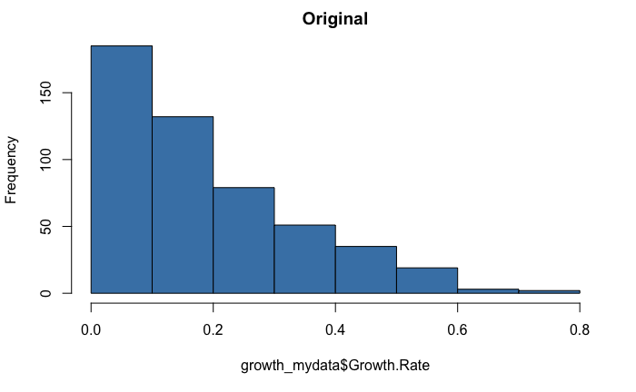

```r
hist(growth_mydata$Growth.Rate,
     col='steelblue',main='Original') #Original data is skewed, let's test for normality and consider log transforming the data
```

```r
shapiro.test(growth_mydata$Growth.Rate)
```

```
    Shapiro-Wilk normality test

data:  growth_mydata$Growth.Rate
W = 0.90445, p-value < 2.2e-16
```

Log transform data (https://www.statology.org/transform-data-in-r/)

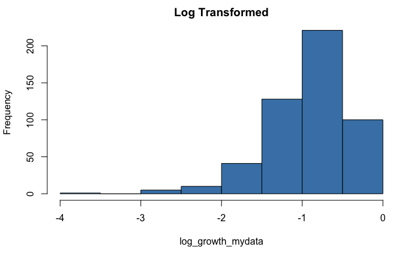

```r
log_growth_mydata<-log10(growth_mydata$Growth.Rate)
hist(log_growth_mydata,
     col='steelblue',main='Log Transformed') #Log transformed data, this looks better than the original distribution
```

```r
shapiro.test(log_growth_mydata) #Data does not improve with log transformation
```

```
    Shapiro-Wilk normality test

data:  log_growth_mydata
W = 0.92178, p-value = 1.503e-15
```

Next I tried a square root transformation, which improved the distribution, but my first model failed the singular fit (see Model 1).

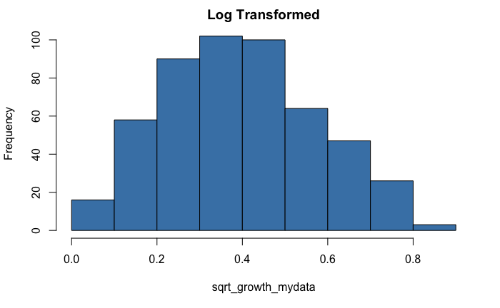

```r
sqrt_growth_mydata<-sqrt(growth_mydata$Growth.Rate)
hist(sqrt_growth_mydata,
     col='steelblue',main='Log Transformed') #Square root transformed data looks better than the original distribution
```

```r
shapiro.test(sqrt_growth_mydata)
```

```
    Shapiro-Wilk normality test

data:  sqrt_growth_mydata
W = 0.98581, p-value = 7.695e-05
```

##Model 1 - lmer: Modeling Habitat and Treatment with Site and Block as random effects

```r
growth_fullmodel1<-lmer(sqrt(Growth.Rate)~Habitat*Treatment+(1|Site)+(1|Block),data=growth_mydata)
```

```
boundary (singular) fit: see help('isSingular')
```

```r
isSingular(growth_fullmodel1,tol=1e-4) #=True
```

```
[1] TRUE
```

```r
summary(growth_fullmodel1) #Variance explained by Site = 0.000
```

```
Linear mixed model fit by REML. t-tests use Satterthwaite's method ['lmerModLmerTest']
Formula: sqrt(Growth.Rate) ~ Habitat * Treatment + (1 | Site) + (1 | Block)
   Data: growth_mydata

REML criterion at convergence: -583.3

Scaled residuals:
     Min       1Q   Median       3Q      Max
-2.61595 -0.69539  0.05978  0.73053  2.88562

Random effects:
 Groups   Name        Variance Std.Dev.
 Block    (Intercept) 0.001598 0.03998
 Site     (Intercept) 0.000000 0.00000
 Residual             0.016171 0.12716
Number of obs: 506, groups:  Block, 10; Site, 8

Fixed effects:
                                              Estimate Std. Error         df t value Pr(>|t|)
(Intercept)                                   0.271164   0.024328  78.070400  11.146  < 2e-16 ***
HabitatVegetated                              0.023733   0.028530 487.902365   0.832  0.40590
TreatmentBiomass Removal                      0.299248   0.025549 488.988743  11.713  < 2e-16 ***
TreatmentHemizonia                            0.009046   0.029694 488.862262   0.305  0.76078
TreatmentRaking                               0.037015   0.028063 487.757926   1.319  0.18778
TreatmentRaking & Clipping                    0.073071   0.027082 488.008833   2.698  0.00722 **
HabitatVegetated:TreatmentBiomass Removal    -0.005098   0.035439 487.461999  -0.144  0.88568
HabitatVegetated:TreatmentHemizonia           0.014342   0.041419 487.869509   0.346  0.72928
HabitatVegetated:TreatmentRaking             -0.022588   0.038582 488.126281  -0.585  0.55852
HabitatVegetated:TreatmentRaking & Clipping  -0.006018   0.037436 488.124609  -0.161  0.87236
---
Signif. codes:  0 ‘***’ 0.001 ‘**’ 0.01 ‘*’ 0.05 ‘.’ 0.1 ‘ ’ 1

Correlation of Fixed Effects:
            (Intr) HbttVg TrtmBR TrtmnH TrtmnR TrtR&C HV:TBR HbV:TH HbV:TR
HabittVgttd -0.614
TrtmntBmssR -0.694  0.584
TretmntHmzn -0.596  0.501  0.567
TretmntRkng -0.626  0.532  0.597  0.512
TrtmntRkn&C -0.650  0.551  0.619  0.533  0.560
HbttVgt:TBR  0.493 -0.804 -0.714 -0.402 -0.428 -0.442
HbttVgtt:TH  0.418 -0.687 -0.398 -0.708 -0.365 -0.378  0.553
HbttVgtt:TR  0.454 -0.741 -0.432 -0.369 -0.726 -0.406  0.596  0.508
HbttVg:TR&C  0.465 -0.761 -0.442 -0.381 -0.403 -0.721  0.612  0.526  0.564
optimizer (nloptwrap) convergence code: 0 (OK)
boundary (singular) fit: see help('isSingular')
```

```r
anova(growth_fullmodel1)
```

```
Type III Analysis of Variance Table with Satterthwaite's method
                  Sum Sq Mean Sq NumDF  DenDF  F value  Pr(>F)
Habitat           0.0464 0.04642     1 488.79   2.8709 0.09083 .
Treatment         7.4582 1.86456     4 489.79 115.3056 < 2e-16 ***
Habitat:Treatment 0.0146 0.00366     4 487.95   0.2260 0.92382
---
Signif. codes:  0 ‘***’ 0.001 ‘**’ 0.01 ‘*’ 0.05 ‘.’ 0.1 ‘ ’ 1
```

Site as a random effect does not explain any of the variance in the model, therefore let’s try Site as a fixed effect to see if it adds to the model.

##Model 2 - lmer: Modeling Site as a fixed effect and Block as a random effect

```r
growth_fullmodel2<-lmer(log(Growth.Rate)~
                          Habitat*Treatment+
                          Site+
                          (1|Block),
                        data=growth_mydata)
summary(growth_fullmodel2) #As a fixed effect, one of the Sites (OAP) is significant.
```

```
Linear mixed model fit by REML. t-tests use Satterthwaite's method ['lmerModLmerTest']
Formula: log(Growth.Rate) ~ Habitat * Treatment + Site + (1 | Block)
   Data: growth_mydata

REML criterion at convergence: 1374.5

Scaled residuals:
    Min      1Q  Median      3Q     Max
-6.2000 -0.4782  0.1779  0.6492  1.8316

Random effects:
 Groups   Name        Variance Std.Dev.
 Block    (Intercept) 0.06789  0.2606
 Residual             0.82580  0.9087
Number of obs: 506, groups:  Block, 10

Fixed effects:
                                              Estimate Std. Error         df t value Pr(>|t|)
(Intercept)                                  -2.984938   0.204110 165.530302 -14.624  < 2e-16 ***
HabitatVegetated                              0.220653   0.204078 480.955621   1.081  0.28014
TreatmentBiomass Removal                      1.729151   0.183091 482.054827   9.444  < 2e-16 ***
TreatmentHemizonia                            0.196272   0.212666 481.942503   0.923  0.35651
TreatmentRaking                               0.346745   0.201477 480.773125   1.721  0.08589 .
TreatmentRaking & Clipping                    0.547314   0.194472 480.894171   2.814  0.00509 **
SiteCHE                                       0.039617   0.163190 481.278240   0.243  0.80829
SiteGUA                                      -0.006678   0.163292 481.229118  -0.041  0.96740
SiteLEX                                      -0.063730   0.164176 481.225590  -0.388  0.69805
SiteOAP                                       0.329379   0.161428 481.228603   2.040  0.04186 *
SitePAR                                       0.105935   0.165141 480.587844   0.641  0.52152
SitePEN                                       0.115262   0.167219 481.510246   0.689  0.49098
SiteSSJ                                       0.112886   0.166554 480.788469   0.678  0.49824
HabitatVegetated:TreatmentBiomass Removal    -0.152103   0.253524 480.438799  -0.600  0.54882
HabitatVegetated:TreatmentHemizonia           0.048304   0.296429 480.886893   0.163  0.87062
HabitatVegetated:TreatmentRaking             -0.214508   0.276049 481.225843  -0.777  0.43750
HabitatVegetated:TreatmentRaking & Clipping  -0.193752   0.268159 481.243075  -0.723  0.47032
---
Signif. codes:  0 ‘***’ 0.001 ‘**’ 0.01 ‘*’ 0.05 ‘.’ 0.1 ‘ ’ 1
```

```
Correlation matrix not shown by default, as p = 17 > 12.
Use print(x, correlation=TRUE)  or
    vcov(x)        if you need it
```

```r
anova(growth_fullmodel2) #Site as a fixed effect accounts for 3% of the variance
```

```
Type III Analysis of Variance Table with Satterthwaite's method
                   Sum Sq Mean Sq NumDF  DenDF F value Pr(>F)
Habitat             1.636   1.636     1 482.01  1.9816 0.1599
Treatment         211.245  52.811     4 483.04 63.9513 <2e-16 ***
Site                6.623   0.946     7 481.06  1.1457 0.3331
Habitat:Treatment   1.190   0.297     4 481.03  0.3601 0.8370
---
Signif. codes:  0 ‘***’ 0.001 ‘**’ 0.01 ‘*’ 0.05 ‘.’ 0.1 ‘ ’ 1
```

Now we’ll look at the QQ plots and the residuals using DHARMa

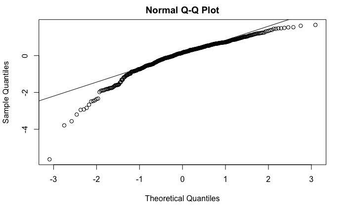

```r
qqnorm(resid(growth_fullmodel2)) #qqplot
qqline(resid(growth_fullmodel2)) #add the line
```

```
    DHARMa nonparametric dispersion test via sd of residuals fitted vs. simulated

data:  simulationOutput
dispersion = 0.97037, p-value = 0.68
alternative hypothesis: two.sided
```

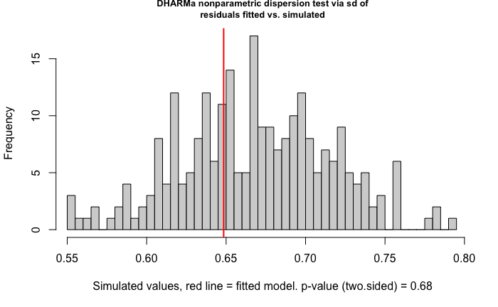

```r
testDispersion(growth_fullmodel2) #red line should be in the middle of the distribution
```

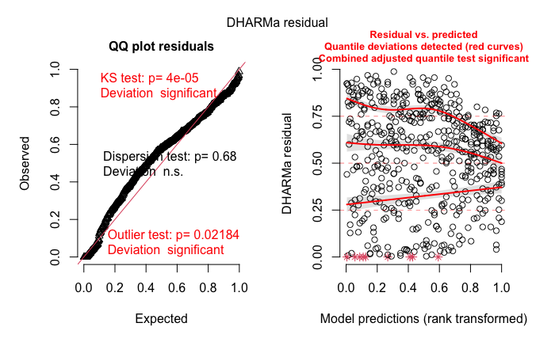

```r
myDHARMagraph2<-simulateResiduals(growth_fullmodel2) #making a graph using DHARMa package, also testing for heteroscedasticity, https://cran.r-project.org/web/packages/DHARMa/vignettes/DHARMa.html#heteroscedasticity
plot(myDHARMagraph2) #plotting graph. At this point, you don't want any text or lines to be red. The QQ plots are not looking good for this model. Let's try fitting to a negative binomial distribution.
```

##Model 4 - glmm: Beta Distribution Now I’m using glmm because I’m fitting to other distributions (beta)

```r
growth_fullmodel4<-glmmTMB(Growth.Rate~
                             Habitat*Treatment+
                             (1|Site)+
                             (1|Block),
                           family=beta_family(),
                           data=growth_mydata)
summary(growth_fullmodel4)
```

```
 Family: beta  ( logit )
Formula:          Growth.Rate ~ Habitat * Treatment + (1 | Site) + (1 | Block)
Data: growth_mydata

     AIC      BIC   logLik deviance df.resid
  -989.3   -934.4    507.7  -1015.3      493

Random effects:

Conditional model:
 Groups Name        Variance  Std.Dev.
 Site   (Intercept) 0.0002645 0.01626
 Block  (Intercept) 0.0429336 0.20720
Number of obs: 506, groups:  Site, 8; Block, 10

Dispersion parameter for beta family (): 11.4

Conditional model:
                                            Estimate Std. Error z value Pr(>|z|)
(Intercept)                                 -2.27681    0.14929 -15.251   <2e-16 ***
HabitatVegetated                             0.12961    0.17864   0.726    0.468
TreatmentBiomass Removal                     1.60566    0.15070  10.655   <2e-16 ***
TreatmentHemizonia                           0.07352    0.18737   0.392    0.695
TreatmentRaking                              0.20030    0.17566   1.140    0.254
TreatmentRaking & Clipping                   0.41358    0.16659   2.483    0.013 *
HabitatVegetated:TreatmentBiomass Removal   -0.03513    0.20401  -0.172    0.863
HabitatVegetated:TreatmentHemizonia          0.10730    0.25788   0.416    0.677
HabitatVegetated:TreatmentRaking            -0.09786    0.23867  -0.410    0.682
HabitatVegetated:TreatmentRaking & Clipping -0.06623    0.22709  -0.292    0.771
---
Signif. codes:  0 ‘***’ 0.001 ‘**’ 0.01 ‘*’ 0.05 ‘.’ 0.1 ‘ ’ 1
```

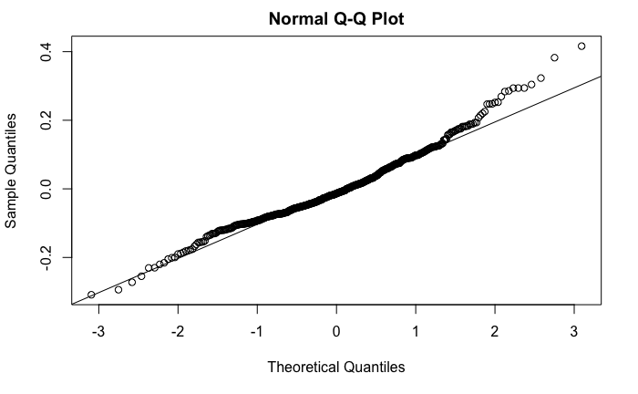

```r
qqnorm(resid(growth_fullmodel4)) #qqplot
qqline(resid(growth_fullmodel4)) #add the line
```

```
    DHARMa nonparametric dispersion test via sd of residuals fitted vs. simulated

data:  simulationOutput
dispersion = 0.97597, p-value = 0.84
alternative hypothesis: two.sided
```

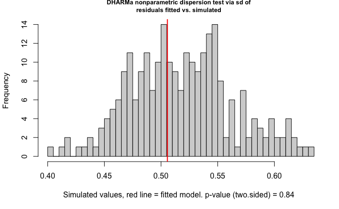

```r
testDispersion(growth_fullmodel4) #red line should be in the middle of the distribution
```

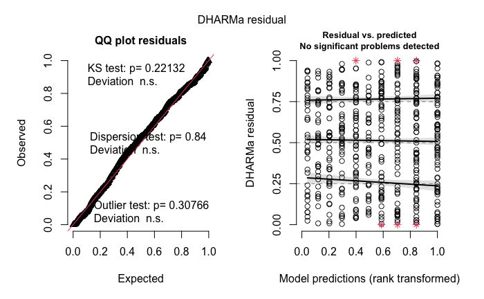

```r
myDHARMagraph4<-simulateResiduals(growth_fullmodel4) #making a graph using DHARMa package, also testing for heteroscedasticity, https://cran.r-project.org/web/packages/DHARMa/vignettes/DHARMa.html#heteroscedasticity
plot(myDHARMagraph4) #plotting graph. Looks good, but check the outliers to make sure they are real.
```

We should check the outliers in the the DHARMa plot to make sure they make sense.

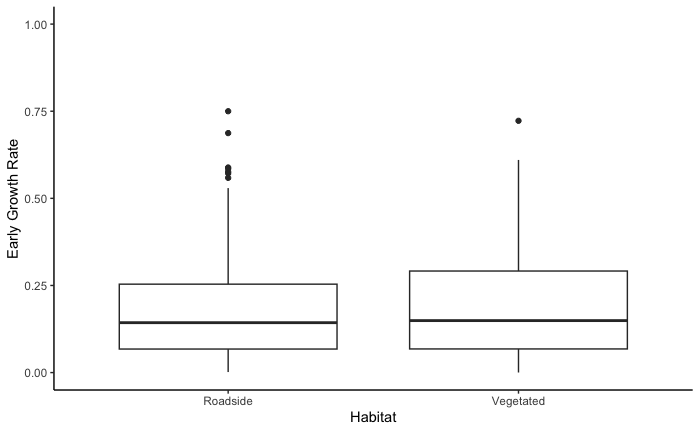

```r
growth_outlier_boxplot1<-ggplot(growth_mydata)+
  geom_boxplot(aes(x=Habitat,
                   y=Growth.Rate),
               size=0.5)+
  theme_classic()+
  ylim(0,1)+
  scale_fill_manual(values=c("forestgreen","gray85"))+
  labs(y="Early Growth Rate",
       fill="Habitat",
       x="Habitat")
growth_outlier_boxplot1
```

```r
max(growth_mydata$Growth.Rate[growth_mydata$Habitat=="Away"])
```

```
[1] -Inf
```

```r
max(growth_mydata$Growth.Rate[growth_mydata$Habitat=="Roadside"]) #Yes, these outliers make sense, so I don't need to worry about the red stars in the DHARMa plot.
```

```
[1] 0.75
```

###Best Model

```r
growth_fullmodel4<-glmmTMB(Growth.Rate~
                             Habitat*Treatment+
                             (1|Site)+
                             (1|Block),
                           family=beta_family(),
                           data=growth_mydata)
summary(growth_fullmodel4)
```

```
 Family: beta  ( logit )
Formula:          Growth.Rate ~ Habitat * Treatment + (1 | Site) + (1 | Block)
Data: growth_mydata

     AIC      BIC   logLik deviance df.resid
  -989.3   -934.4    507.7  -1015.3      493

Random effects:

Conditional model:
 Groups Name        Variance  Std.Dev.
 Site   (Intercept) 0.0002645 0.01626
 Block  (Intercept) 0.0429336 0.20720
Number of obs: 506, groups:  Site, 8; Block, 10

Dispersion parameter for beta family (): 11.4

Conditional model:
                                            Estimate Std. Error z value Pr(>|z|)
(Intercept)                                 -2.27681    0.14929 -15.251   <2e-16 ***
HabitatVegetated                             0.12961    0.17864   0.726    0.468
TreatmentBiomass Removal                     1.60566    0.15070  10.655   <2e-16 ***
TreatmentHemizonia                           0.07352    0.18737   0.392    0.695
TreatmentRaking                              0.20030    0.17566   1.140    0.254
TreatmentRaking & Clipping                   0.41358    0.16659   2.483    0.013 *
HabitatVegetated:TreatmentBiomass Removal   -0.03513    0.20401  -0.172    0.863
HabitatVegetated:TreatmentHemizonia          0.10730    0.25788   0.416    0.677
HabitatVegetated:TreatmentRaking            -0.09786    0.23867  -0.410    0.682
HabitatVegetated:TreatmentRaking & Clipping -0.06623    0.22709  -0.292    0.771
---
Signif. codes:  0 ‘***’ 0.001 ‘**’ 0.01 ‘*’ 0.05 ‘.’ 0.1 ‘ ’ 1
```

###Post-Hoc Test Remove non-significant interaction terms before running the Tukey.

```r
#?emmeans,emmeans(model,pairwise~treatment)
growth_fullmodel4.1<-glmmTMB(Growth.Rate~
                               Treatment+
                               (1|Site)+
                               (1|Block),
                             family=beta_family(),
                             data=growth_mydata)
summary(growth_fullmodel4.1)
```

```
 Family: beta  ( logit )
Formula:          Growth.Rate ~ Treatment + (1 | Site) + (1 | Block)
Data: growth_mydata

     AIC      BIC   logLik deviance df.resid
  -996.0   -962.2    506.0  -1012.0      498

Random effects:

Conditional model:
 Groups Name        Variance  Std.Dev.
 Site   (Intercept) 0.0006051 0.0246
 Block  (Intercept) 0.0416553 0.2041
Number of obs: 506, groups:  Site, 8; Block, 10

Dispersion parameter for beta family (): 11.3

Conditional model:
                           Estimate Std. Error z value Pr(>|z|)
(Intercept)                 -2.2066     0.1144 -19.284  < 2e-16 ***
TreatmentBiomass Removal     1.5835     0.1053  15.043  < 2e-16 ***
TreatmentHemizonia           0.1210     0.1295   0.934  0.35019
TreatmentRaking              0.1507     0.1203   1.253  0.21035
TreatmentRaking & Clipping   0.3781     0.1150   3.287  0.00101 **
---
Signif. codes:  0 ‘***’ 0.001 ‘**’ 0.01 ‘*’ 0.05 ‘.’ 0.1 ‘ ’ 1
```

```r
emmeans(growth_fullmodel4.1,
        pairwise~Treatment)
```

```
$emmeans
 Treatment         emmean     SE  df lower.CL upper.CL
 Grassland         -2.207 0.1144 498   -2.431   -1.982
 Biomass Removal   -0.623 0.0818 498   -0.784   -0.462
 Hemizonia         -2.086 0.1158 498   -2.313   -1.858
 Raking            -2.056 0.1050 498   -2.262   -1.850
 Raking & Clipping -1.828 0.0969 498   -2.019   -1.638

Results are given on the logit (not the response) scale.
Confidence level used: 0.95

$contrasts
 contrast                            estimate     SE  df t.ratio p.value
 Grassland - Biomass Removal          -1.5835 0.1053 498 -15.043  <.0001
 Grassland - Hemizonia                -0.1210 0.1295 498  -0.934  0.8835
 Grassland - Raking                   -0.1507 0.1203 498  -1.253  0.7203
 Grassland - Raking & Clipping        -0.3781 0.1150 498  -3.287  0.0095
 Biomass Removal - Hemizonia           1.4625 0.1071 498  13.658  <.0001
 Biomass Removal - Raking              1.4327 0.0950 498  15.081  <.0001
 Biomass Removal - Raking & Clipping   1.2054 0.0864 498  13.956  <.0001
 Hemizonia - Raking                   -0.0298 0.1225 498  -0.243  0.9992
 Hemizonia - Raking & Clipping        -0.2571 0.1170 498  -2.198  0.1822
 Raking - Raking & Clipping           -0.2274 0.1062 498  -2.141  0.2043

Results are given on the log odds ratio (not the response) scale.
P value adjustment: tukey method for comparing a family of 5 estimates
```

###Chapter 1 three panel figure

###ggplot ####Interaction plot #####Biomass x Treatment: Growth

[figure not shown]

#####Growth Rate x Treatment: Growth

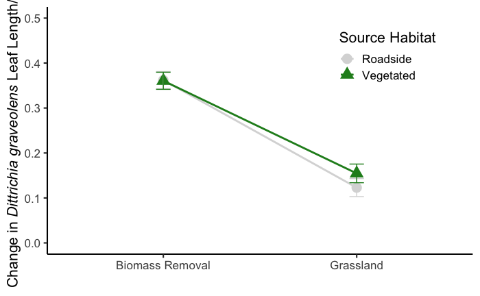

```r
pd<-position_dodge(0)

growth_mydata2<-growth_mydata%>%
  replace_na(list(Growth.Rate=0))%>%
  filter(CensorReproduction==1)%>%
  filter(Treatment=="Biomass Removal"|Treatment=="Grassland")%>%
  group_by(Treatment,Habitat)%>%
  summarise(Mean=mean(Growth.Rate),
            SD=sd(Growth.Rate),
            N=length(Growth.Rate))%>%
  mutate(SE=SD/sqrt(N))
field_int_rate_grow_gg<-ggplot(growth_mydata2,
                        aes(x=factor(Treatment,levels=c("Biomass Removal","Grassland")),
                            y=Mean,
                            shape=Habitat,
                            group=Habitat,
                            color=Habitat))+
  coord_cartesian(ylim = c(0,0.5))+
  xlab("")+
  theme_bw(base_size=16)+
  theme(panel.border=element_blank(),
        panel.grid.major=element_blank(),
        panel.grid.minor=element_blank(),
        axis.line=element_line(colour="black"),
        axis.title.y=ggtext::element_markdown(),
        legend.position = c(0.8, 0.8))+
 # ggtitle("Growth of Dittrichia graveolens that budded")+
  ylab("*Dittrichia graveolens* \n (Change in Leaf Length/Days)")+
  geom_line(size=1,
            position=pd)+
  geom_point(size=5,
             position=pd)+
  scale_color_manual(values=c("gray85","forestgreen"))+
  geom_errorbar(width=0.15,
                position=pd,
                aes(ymin=(Mean-SE),
                    ymax=(Mean+SE)))+
  labs(y="Change in *Dittrichia graveolens* Leaf Length/Day",
       color="Source Habitat",
       shape="Source Habitat")
field_int_rate_grow_gg
```

```r
#ggsave(plot=field_int_rate_grow_gg,file="/Users/Miranda/Documents/Education/UC Santa Cruz/Dittrichia/Dittrichia_Analysis/figures/field_int_rate_grow_gg.png",width=25,height=15,units="cm",dpi=800)
```

####Boxplot

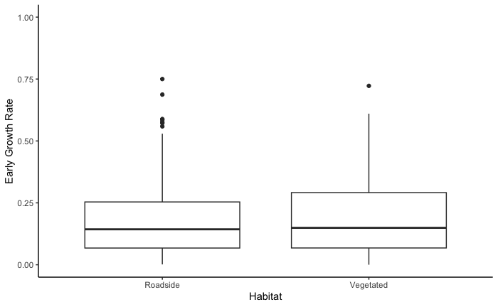

```r
#Boxplot with Early Growth Rate by Habitat
growth_boxplot1<-ggplot(growth_mydata)+
  geom_boxplot(aes(x=Habitat,
                   y=Growth.Rate),
               size=0.5)+
  theme_classic()+
  ylim(0,1)+
  scale_fill_manual(values=c("forestgreen","gray58"))+
  labs(y="Early Growth Rate",
       fill="Habitat",
       x="Habitat")
growth_boxplot1
```

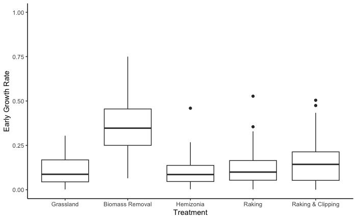

```r
#ggsave(plot=growth_boxplot1,file="/Users/Miranda/Documents/Education/UC Santa Cruz/Dittrichia/Dittrichia_Analysis/figures/growth_boxplot1.png",width=20,height=20,units="cm",dpi=800)

#Boxplot with Early Growth Rate by All Treatments
growth_boxplot2<-ggplot(growth_mydata)+
  geom_boxplot(aes(x=Treatment,
                   y=Growth.Rate),
               size=0.5)+
  theme_classic()+
  ylim(0,1)+
  scale_fill_manual(values=c("forestgreen","gray85"))+
  labs(y="Early Growth Rate",
       fill="Habitat",
       x="Treatment")
growth_boxplot2
```

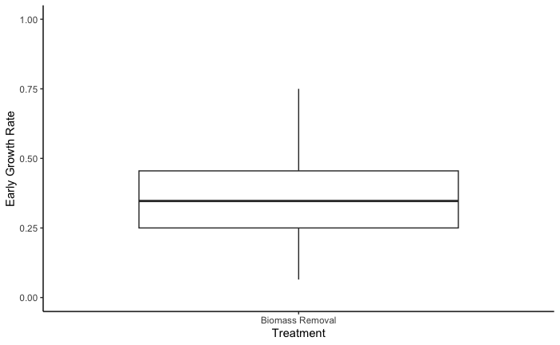

```r
#ggsave(plot=growth_boxplot2,file="/Users/Miranda/Documents/Education/UC Santa Cruz/Dittrichia/Dittrichia_Analysis/figures/growth_boxplot2.png",width=20,height=20,units="cm",dpi=800)

#Boxplot with Early Growth Rate by 2 treatments (Control and Biomass Removal)
sub_growth_mydata<-subset(growth_mydata,
                          Treatment%in%c('Control','Biomass Removal'))

growth_boxplot3<-ggplot(sub_growth_mydata)+
  geom_boxplot(aes(x=Treatment,
                   y=Growth.Rate),
               size=0.5)+
  theme_classic()+
  ylim(0,1)+
  scale_fill_manual(values=c("forestgreen","gray85"))+
  labs(y="Early Growth Rate",
       fill="Habitat",
       x="Treatment")
growth_boxplot3
```

```r
#ggsave(plot=growth_boxplot3,file="/Users/Miranda/Documents/Education/UC Santa Cruz/Dittrichia/Dittrichia_Analysis/figures/growth_boxplo3.png",width=20,height=20,units="cm",dpi=800)
```

#Reproductive Biomass This code uses Biomass data with Habitat (roadside and vegetated) and Treatment in a lmer model. ANOVA and Tukey are used on the successful Model 3 with the creation of a box plot as a finished product.

Note: 10 blocks, 5 treatments, 16 populations (CHE-O), 8 sites (random: population pairs; CHE), 2 habitat (fixed effect: roadside and vegetated; R or O)

Also Note: Biomass data is a measure of aboveground biomass of all individuals harvested from the site. In some cases this was before they budded, but we harvested the wilted plant in case that information was needed in the future. Here we only want to look at biomass (well, log(Biomass)) for reproductive individuals.

Here we need to subset the data to only look at Biomass when CensorReproduction = 1, so that all Biomass data is for reproductive individuals only.

```r
reproduction_mydata<-subset(mydata,CensorReproduction%in%c('1')) #Here I am only looking at the Biomass data where the CensorReproduction = 1
```

##Histograms

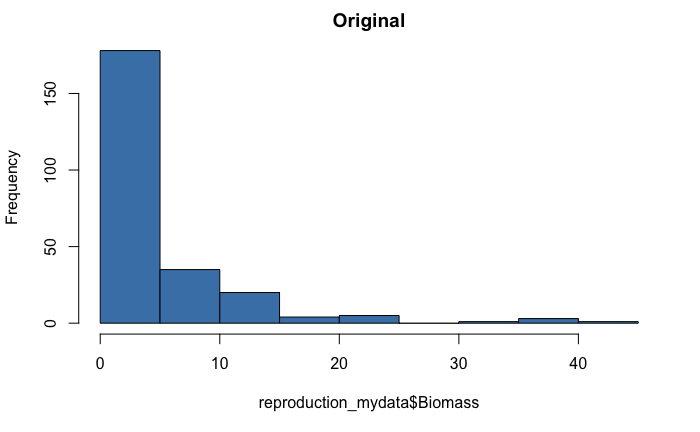

```r
hist(reproduction_mydata$Biomass,col='steelblue',main='Original') #Original data is skewed, let's test for normality and consider log transforming the data
```

```r
shapiro.test(reproduction_mydata$Biomass)
```

```
    Shapiro-Wilk normality test

data:  reproduction_mydata$Biomass
W = 0.62548, p-value < 2.2e-16
```

Log transform data (https://www.statology.org/transform-data-in-r/)

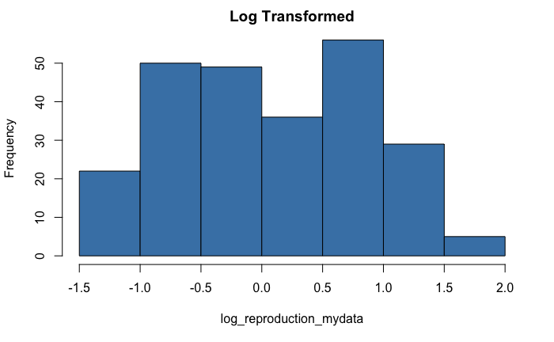

```r
log_reproduction_mydata<-log10(reproduction_mydata$Biomass)
hist(log_reproduction_mydata,col='steelblue',main='Log Transformed') #Log transformed data, this looks better than the original distribution
```

```r
shapiro.test(log_reproduction_mydata)
```

```
    Shapiro-Wilk normality test

data:  log_reproduction_mydata
W = 0.9648, p-value = 9.101e-06
```

```r
#Log transformed data has a better distribution than the original data so we will use the log transformed data with our models
```

##Model 1 - lmer: Modeling Habitat and Treatment with Site and Block as random effects

```r
fullmodel1<-lmer(log(Biomass)~
                   Habitat*Treatment+
                   (1|Site)+
                   (1|Block),
                 data=reproduction_mydata)
isSingular(fullmodel1,tol=1e-4)
```

```
[1] FALSE
```

```r
summary(fullmodel1) #Variance explained by Site = 0.000
```

```
Linear mixed model fit by REML. t-tests use Satterthwaite's method ['lmerModLmerTest']
Formula: log(Biomass) ~ Habitat * Treatment + (1 | Site) + (1 | Block)
   Data: reproduction_mydata

REML criterion at convergence: 675.3

Scaled residuals:
    Min      1Q  Median      3Q     Max
-3.2251 -0.6836  0.0555  0.6095  2.9640

Random effects:
 Groups   Name        Variance  Std.Dev.
 Block    (Intercept) 0.1836330 0.42852
 Site     (Intercept) 0.0003818 0.01954
 Residual             0.8322599 0.91228
Number of obs: 247, groups:  Block, 10; Site, 8

Fixed effects:
                                             Estimate Std. Error        df t value Pr(>|t|)
(Intercept)                                  -1.47119    0.25189  65.18355  -5.841  1.8e-07 ***
HabitatVegetated                              0.52617    0.31275 229.17635   1.682   0.0939 .
TreatmentBiomass Removal                      3.16732    0.24296 227.53081  13.036  < 2e-16 ***
TreatmentHemizonia                           -0.05905    0.31382 229.47907  -0.188   0.8509
TreatmentRaking                               0.25358    0.41060 211.72838   0.618   0.5375
TreatmentRaking & Clipping                    0.54416    0.31428 229.25370   1.731   0.0847 .
HabitatVegetated:TreatmentBiomass Removal    -0.59897    0.35315 229.14685  -1.696   0.0912 .
HabitatVegetated:TreatmentHemizonia          -0.30666    0.44327 228.66064  -0.692   0.4898
HabitatVegetated:TreatmentRaking             -0.20197    0.55618 220.56602  -0.363   0.7168
HabitatVegetated:TreatmentRaking & Clipping  -0.79028    0.43205 229.37117  -1.829   0.0687 .
---
Signif. codes:  0 ‘***’ 0.001 ‘**’ 0.01 ‘*’ 0.05 ‘.’ 0.1 ‘ ’ 1

Correlation of Fixed Effects:
            (Intr) HbttVg TrtmBR TrtmnH TrtmnR TrtR&C HV:TBR HbV:TH HbV:TR
HabittVgttd -0.564
TrtmntBmssR -0.738  0.582
TretmntHmzn -0.558  0.439  0.582
TretmntRkng -0.445  0.351  0.463  0.342
TrtmntRkn&C -0.570  0.455  0.591  0.450  0.361
HbttVgt:TBR  0.500 -0.883 -0.675 -0.390 -0.309 -0.403
HbttVgtt:TH  0.392 -0.702 -0.404 -0.690 -0.246 -0.316  0.619
HbttVgtt:TR  0.319 -0.556 -0.331 -0.252 -0.723 -0.258  0.490  0.391
HbttVg:TR&C  0.413 -0.727 -0.425 -0.316 -0.262 -0.725  0.641  0.507  0.405
```

```r
anova(fullmodel1)
```

```
Type III Analysis of Variance Table with Satterthwaite's method
                  Sum Sq Mean Sq NumDF  DenDF  F value Pr(>F)
Habitat             0.84   0.843     1 229.56   1.0133 0.3152
Treatment         483.42 120.855     4 228.83 145.2134 <2e-16 ***
Habitat:Treatment   3.83   0.957     4 226.65   1.1497 0.3340
---
Signif. codes:  0 ‘***’ 0.001 ‘**’ 0.01 ‘*’ 0.05 ‘.’ 0.1 ‘ ’ 1
```

```r
#Site as a random effect does not explain any of the variance in the model, therefore let's try Site as a fixed effect to demonstrate that it doesn't add to the model.
predict(fullmodel1)
```

[output not shown]

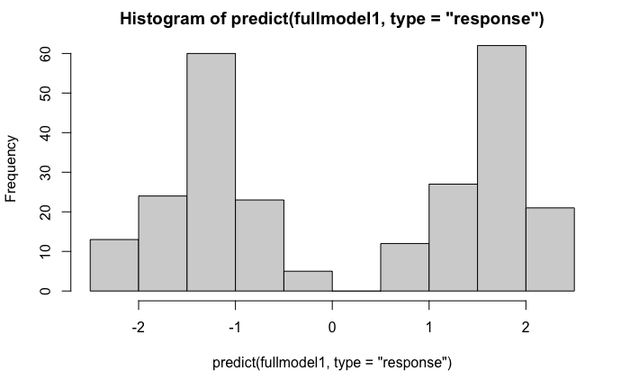

```r
hist(predict(fullmodel1,type="response"))
```

##Model 2 - lmer: Modeling Site as a fixed effect

```r
fullmodel2<-lmer(log(Biomass)~
                   Habitat*Treatment+
                   Site+
                   (1|Block),
                 data=reproduction_mydata)
summary(fullmodel2)
```

```
Linear mixed model fit by REML. t-tests use Satterthwaite's method ['lmerModLmerTest']
Formula: log(Biomass) ~ Habitat * Treatment + Site + (1 | Block)
   Data: reproduction_mydata

REML criterion at convergence: 678.3

Scaled residuals:
    Min      1Q  Median      3Q     Max
-3.2839 -0.6210  0.0399  0.5639  2.7969

Random effects:
 Groups   Name        Variance Std.Dev.
 Block    (Intercept) 0.1650   0.4062
 Residual             0.8361   0.9144
Number of obs: 247, groups:  Block, 10

Fixed effects:
                                              Estimate Std. Error         df t value Pr(>|t|)
(Intercept)                                  -1.720266   0.285577 105.107873  -6.024 2.54e-08 ***
HabitatVegetated                              0.488869   0.318875 223.009734   1.533   0.1267
TreatmentBiomass Removal                      3.161011   0.244374 223.621849  12.935  < 2e-16 ***
TreatmentHemizonia                           -0.004785   0.317523 223.398880  -0.015   0.9880
TreatmentRaking                               0.156859   0.426831 224.250434   0.367   0.7136
TreatmentRaking & Clipping                    0.509433   0.317070 223.835290   1.607   0.1095
SiteCHE                                       0.355322   0.232174 223.497740   1.530   0.1273
SiteGUA                                       0.410402   0.245081 221.592351   1.675   0.0954 .
SiteLEX                                       0.356617   0.233876 222.425736   1.525   0.1287
SiteOAP                                       0.316128   0.234233 222.925291   1.350   0.1785
SitePAR                                      -0.001442   0.231840 221.753218  -0.006   0.9950
SitePEN                                       0.347827   0.244024 223.399330   1.425   0.1554
SiteSSJ                                       0.315678   0.237514 222.147337   1.329   0.1852
HabitatVegetated:TreatmentBiomass Removal    -0.556028   0.358662 222.367673  -1.550   0.1225
HabitatVegetated:TreatmentHemizonia          -0.363654   0.452306 222.295756  -0.804   0.4223
HabitatVegetated:TreatmentRaking             -0.059139   0.573956 221.764455  -0.103   0.9180
HabitatVegetated:TreatmentRaking & Clipping  -0.744475   0.440856 223.170989  -1.689   0.0927 .
---
Signif. codes:  0 ‘***’ 0.001 ‘**’ 0.01 ‘*’ 0.05 ‘.’ 0.1 ‘ ’ 1
```

```
Correlation matrix not shown by default, as p = 17 > 12.
Use print(x, correlation=TRUE)  or
    vcov(x)        if you need it
```